# Zadanie 5

Olaf Werner

April 28, 2019

## Zbiór Danych

[figure not shown]

Będziemy operować na zbiorze danych z [kaggla](https://www.kaggle.com/broaniki/titanic) o losach pasażerów Tytanica. Naszym celem będzie predykcja tego czy dana osoba przeżyje czy nie. Miarą określającą jakość modelu będzie AUC. Zrobiłem na zbiorze małe modyfikacje. Po pierwsze usunołem kolumny Name, PassengerId, Ticket ponieważ nie niosły żadnej informacji. Po drugie kolumnę Cabin zmieniłem na wartość logiczną określającą czy dana osoba miała w ogóle jakąś kabinę.

## Hiperparametry drzew

Model rpart ma różne parametry my skupimy się na następujących:

1. **maxdepth** czyli maksymalna głębokośc drzewa, gdzie korzen uznajemy ze ma głębokość 0
2. **minsplit** to minimalna ilosc obserwacji dla ktorej mozemy dalej dzielic dany węzeł
3. **minbucket** to minimalna ilość obserwacji w lisciu
4. **cp** to stopień złożoności drzewa. Oznacza to że jeżeli podział węzła nie zmiejsza ogólnego braku dopasowania o co najmniej cp to się go nie dzieli.

## Ustawiamy parametry modeli

Ustawiłem parametry jednego z modeli zgodnie z treścią [artykułu](https://arxiv.org/pdf/1802.09596.pdf)

```r
task <- makeClassifTask(id = "task", data = train, target = "Survived")
learner_default<-makeLearner("classif.rpart",predict.type = "prob")
learner_article<-makeLearner("classif.rpart",predict.type = "prob",par.vals = list(cp=0.001,maxdepth=13,minbucket=12,minsplit=18))
rpart_pars <- tuneParams(
  makeLearner("classif.rpart",predict.type = "prob"),
  subsetTask(makeClassifTask(id = "task", data = train, target = "Survived")),
  resampling = cv5,
  measures = mlr::auc,
  par.set = makeParamSet(
    makeNumericParam("cp",lower = 0,upper = 1),
    makeDiscreteParam("maxdepth", values = 1:30),
    makeDiscreteParam("minbucket", values = 1:40),
    makeDiscreteParam("minsplit", values = 1:40)
  ),
  control = makeTuneControlRandom(maxit = 200), show.info=FALSE
  )
learner_random<-makeLearner("classif.rpart",predict.type = "prob",par.vals = rpart_pars$x)
```

## Porównanie wyników

|  | auc.test.mean |
| --- | --- |
| article | 0.8462112 |
| default | 0.8364164 |
| random | 0.8295648 |

Jak widzimy najlepszym modelem okazał się ten proponowany przez artykuł, choć różnice były niewielkie

## Drzewo decyzyjne dla modelu proponowanego przez artykuł

Pokazujemy drzewo które zostało wytrenowane na pełnych danych.

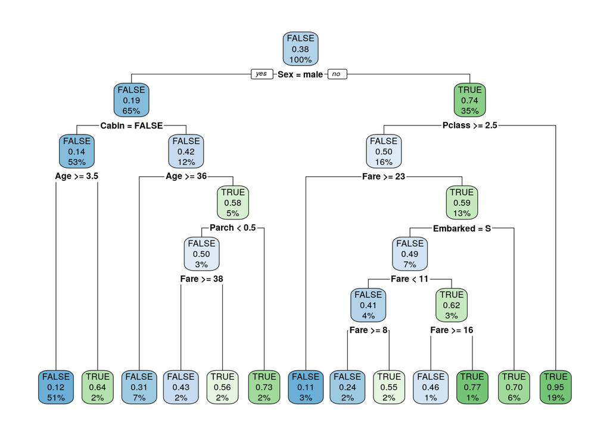

Jak widzimy najważniejszą cechą jest płeć danej osoby, a później w zależności od płci klasa lub posiadanie kabiny, czyli ogólnie lepiej być kobietą i mieć pieniądze by przeżyć katastrofę Tytanica.

## Porównanie drzew domyślych ze zmienionym kryterium podziału

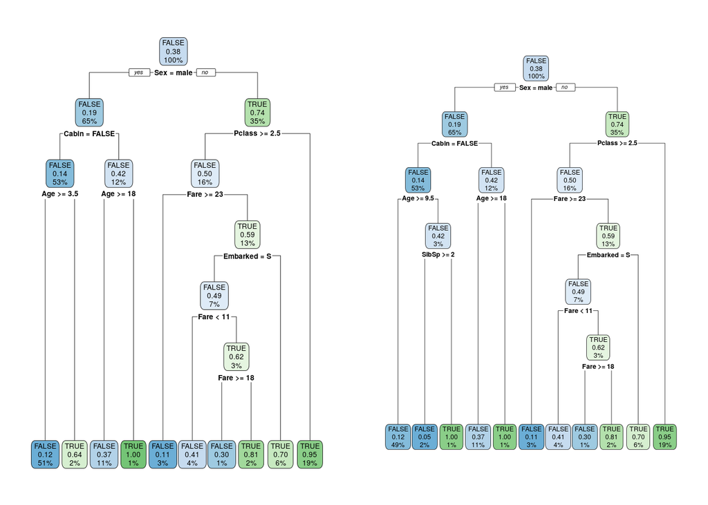

Nie ma w tym przypadku wielkich różnic.